# 6 SLAI Version 2.0

Authors

Affiliations

Lars Hinrichs

The University of Texas at Austin

Stefan Dollinger

University of British Columbia

## 1 Data prep

```
# A tibble: 2,484 × 36
   region gender province    cool  multiling umultiling comf_non_eng media priv
   <fct>  <fct>  <fct>       <chr> <chr>     <chr>      <chr>        <chr> <chr>
 1 BC     female British Co… stro… definite… no         <NA>         extr… "yes"
 2 BC     female British Co… stro… probably… no         <NA>         impo… "no"
 3 BC     male   United Sta… stro… probably… no         <NA>         extr… "tha…
 4 US     other  British Co… stro… probably… yes        extremely c… unim… "tha…
 5 BC     other  Quebec      stro… probably… yes        moderately … impo… "no"
 6 BC     male   British Co… stro… probably… no         <NA>         impo… "tha…
 7 ON     female Ontario     agree probably… no         <NA>         impo… "tha…
 8 BC     female British Co… agree definite… yes        neither com… <NA>  "tha…
 9 MB     male   British Co… stro… definite… no         <NA>         impo… "tha…
10 AB     male   British Co… agree definite… no         <NA>         impo… "yes"
# ℹ 2,474 more rows
# ℹ 27 more variables: st_heard <chr>, st_descr <chr>, zed <chr>, spell <chr>,
#   spell_uni <chr>, distinct <chr>, same_ew <chr>, celebs <chr>,
#   prestige <chr>, rec_cdns <chr>, software <chr>, dictionary <chr>,
#   recog_eh <chr>, cdn_sorry <chr>, engl_able <chr>, fr_able <chr>,
#   ind_able <chr>, beyond_ef <chr>, cdn_way <chr>, age <int>, country <chr>,
#   edu_comp <chr>, degree_year <chr>, eui <chr>, dist_cult <chr>, eoi <chr>, …
```

Next, we address comparability among survey questions. Some questions use a 4-point Likert scale, others a 5-point scale. We **rescale the 4-point Likert items to a 5-point scale** in order to make them comparable with the 5-point items.

## 2 Forming the SLAI

Let us consider forming an index variable of responses to the following questions:

### 2.1 DVs

Response variables (ordinal or categorical):

- `st_heard`: yes / no / not sure
- `spell_uni`: Likert-style (5 levels)
- `distinct`: Likert-style (4 levels)
- `cdn_way`: Likert-style (4 levels)
- `spell`: Likert-style (5 levels)

### 2.3 Justification of SLAI

The DVs listed above represent a battery of attitude elicitation questions that are, at the theoretical level, *reflective* of an overall attitude toward the concept of Standard Canadian English. We must assume, therefore, that these variables *covary*. If we can show high internal consistency, it is reasonable to treat their arithmetic mean as a single factor.

We are considering these variables in their numeric conversions that have been scaled to a 5-level scale. The converted variables are named:

- `st_heard_scaled`
- `spell_uni_scaled`
- `distinct_scaled`
- `cdn_way_scaled`
- `spell_scaled`

In order to test them for consistency, we begin by exploring them in terms of basic distribution statistics.

#### 2.3.1 Inspect distributions

```
                           [,1]
st_heard_scaled_mean  3.3807987
st_heard_scaled_sd    1.8066917
spell_uni_scaled_mean 3.9106472
spell_uni_scaled_sd   1.1745844
distinct_scaled_mean  3.6327783
distinct_scaled_sd    1.0661865
cdn_way_scaled_mean   3.8877193
cdn_way_scaled_sd     0.8802655
spell_scaled_mean     3.6757637
spell_scaled_sd       1.0949071
```

Visualize distribution of a single variable.

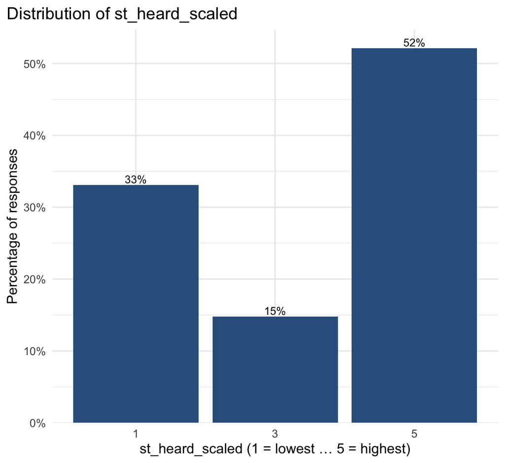

Figure 1

Instead of making separate plots, let’s viz all the attitude-relevant vars in one plot.

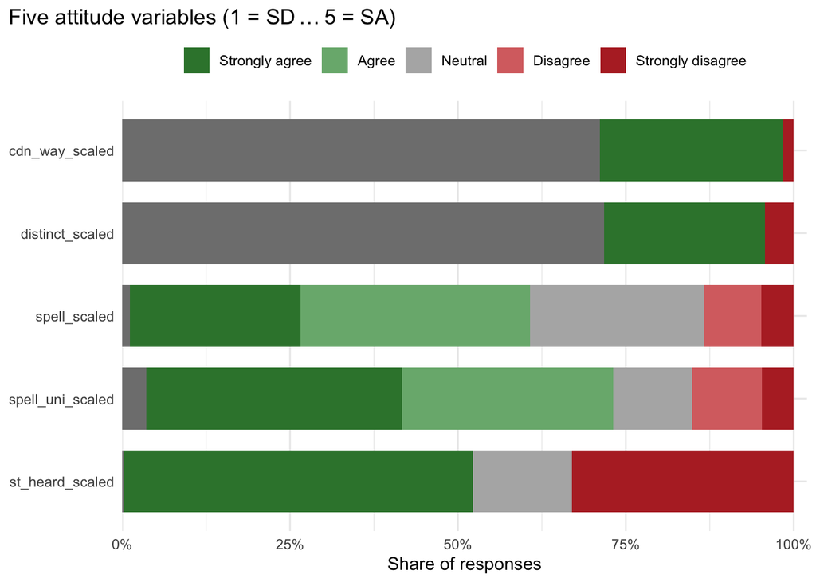

Figure 2

#### 2.3.2 Compute internal consistency

Next we calculate Cronbach’s α.

**Cronbach’s α**

Rule of thumb: α ≥ .70 for research, α ≥ .80 for high‑stakes decisions (Nunnally & Bernstein, 1994).

```
Reliability analysis
Call: psych::alpha(x = df_canada[, c(attitude_vars)])

  raw_alpha std.alpha G6(smc) average_r S/N   ase mean  sd median_r
      0.61      0.66    0.66      0.28   2 0.013  3.7 0.8     0.27

    95% confidence boundaries
         lower alpha upper
Feldt     0.58  0.61  0.63
Duhachek  0.58  0.61  0.63

 Reliability if an item is dropped:
                 raw_alpha std.alpha G6(smc) average_r S/N alpha se var.r med.r
st_heard_scaled       0.70      0.70    0.68      0.36 2.3   0.0098 0.022  0.30
spell_uni_scaled      0.51      0.57    0.51      0.25 1.3   0.0159 0.010  0.24
distinct_scaled       0.53      0.59    0.58      0.27 1.5   0.0157 0.038  0.21
cdn_way_scaled        0.55      0.61    0.60      0.28 1.6   0.0150 0.037  0.24
spell_scaled          0.49      0.56    0.50      0.24 1.3   0.0164 0.011  0.24

 Item statistics
                    n raw.r std.r r.cor r.drop mean   sd
st_heard_scaled  2479  0.65  0.50  0.26   0.21  3.4 1.81
spell_uni_scaled 2395  0.68  0.71  0.66   0.46  3.9 1.17
distinct_scaled  2282  0.63  0.68  0.54   0.43  3.6 1.07
cdn_way_scaled   2280  0.57  0.65  0.50   0.39  3.9 0.88
spell_scaled     2455  0.69  0.73  0.68   0.49  3.7 1.09

Non missing response frequency for each item
                    1    2 2.33333333333333    3 3.66666666666667    4    5
st_heard_scaled  0.33 0.00             0.00 0.15             0.00 0.00 0.52
spell_uni_scaled 0.05 0.11             0.00 0.12             0.00 0.33 0.39
distinct_scaled  0.05 0.00             0.19 0.00             0.50 0.00 0.26
cdn_way_scaled   0.02 0.00             0.09 0.00             0.59 0.00 0.30
spell_scaled     0.05 0.09             0.00 0.26             0.00 0.35 0.26
                 miss
st_heard_scaled  0.00
spell_uni_scaled 0.04
distinct_scaled  0.08
cdn_way_scaled   0.08
spell_scaled     0.01
```

**Internal consistency finding**

It looks like `st_heard_scaled` causes more trouble than the others. If we leave it out, Cronbach’s α improves the most.

So, let’s leave out `st_heard_scaled` and evaluate again.

```
Reliability analysis
Call: psych::alpha(x = df_canada[, c(attitude_vars[2:5])])

  raw_alpha std.alpha G6(smc) average_r S/N    ase mean   sd median_r
       0.7       0.7    0.68      0.36 2.3 0.0098  3.8 0.78      0.3

    95% confidence boundaries
         lower alpha upper
Feldt     0.68   0.7  0.72
Duhachek  0.68   0.7  0.72

 Reliability if an item is dropped:
                 raw_alpha std.alpha G6(smc) average_r S/N alpha se  var.r
spell_uni_scaled      0.59      0.60    0.50      0.33 1.5    0.014 0.0054
distinct_scaled       0.67      0.66    0.62      0.39 2.0    0.011 0.0475
cdn_way_scaled        0.68      0.68    0.63      0.41 2.1    0.011 0.0410
spell_scaled          0.57      0.59    0.49      0.32 1.4    0.015 0.0064
                 med.r
spell_uni_scaled  0.31
distinct_scaled   0.27
cdn_way_scaled    0.31
spell_scaled      0.28

 Item statistics
                    n raw.r std.r r.cor r.drop mean   sd
spell_uni_scaled 2395  0.80  0.76  0.68   0.55  3.9 1.17
distinct_scaled  2282  0.69  0.69  0.51   0.42  3.6 1.07
cdn_way_scaled   2280  0.63  0.67  0.48   0.40  3.9 0.88
spell_scaled     2455  0.79  0.77  0.70   0.58  3.7 1.09

Non missing response frequency for each item
                    1    2 2.33333333333333    3 3.66666666666667    4    5
spell_uni_scaled 0.05 0.11             0.00 0.12             0.00 0.33 0.39
distinct_scaled  0.05 0.00             0.19 0.00             0.50 0.00 0.26
cdn_way_scaled   0.02 0.00             0.09 0.00             0.59 0.00 0.30
spell_scaled     0.05 0.09             0.00 0.26             0.00 0.35 0.26
                 miss
spell_uni_scaled 0.04
distinct_scaled  0.08
cdn_way_scaled   0.08
spell_scaled     0.01
```

**The takeaway**

We must exclude `st_heard_scaled` in order to form a reliable SLAI.

### 2.4 Calculate SLAI

We calculate the SLAI out of the four variables that passed the consistency test by using the function `rowMeans()`. To prepare for plotting, we also filter out respondents that didn’t answer one of the questions.

We perform similar cleaning for the `edu` and `umultiling` variables.

### 2.5 Univariate dependencies

Begin with `edu`.

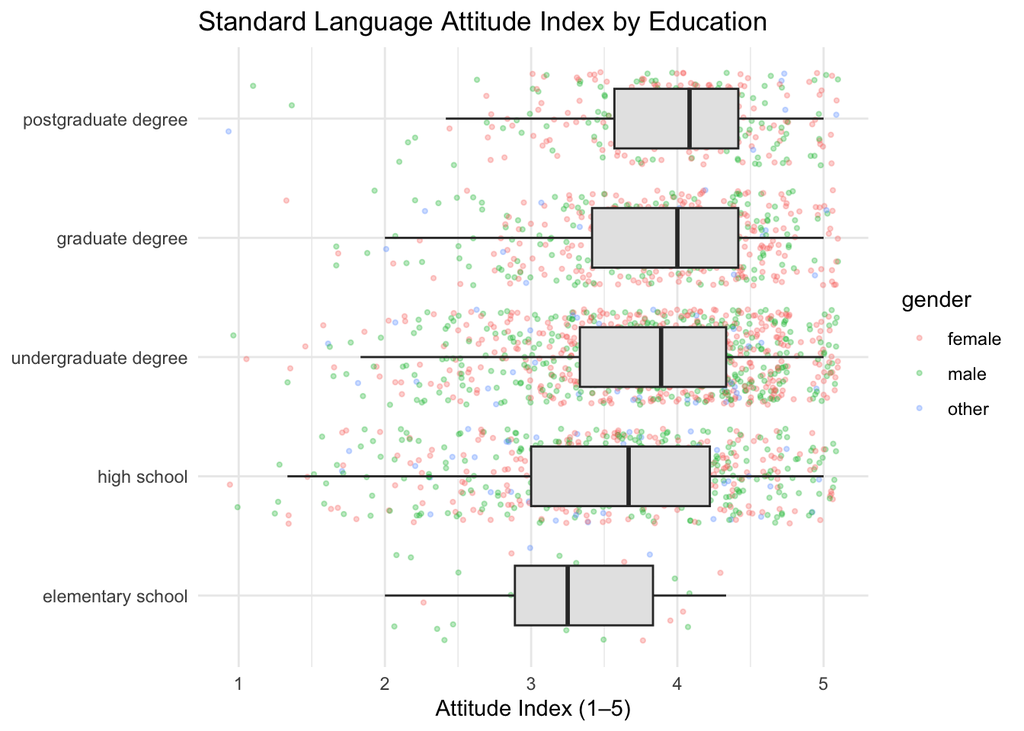

Figure 3

Now plot the interaction `edu` x `gender.`

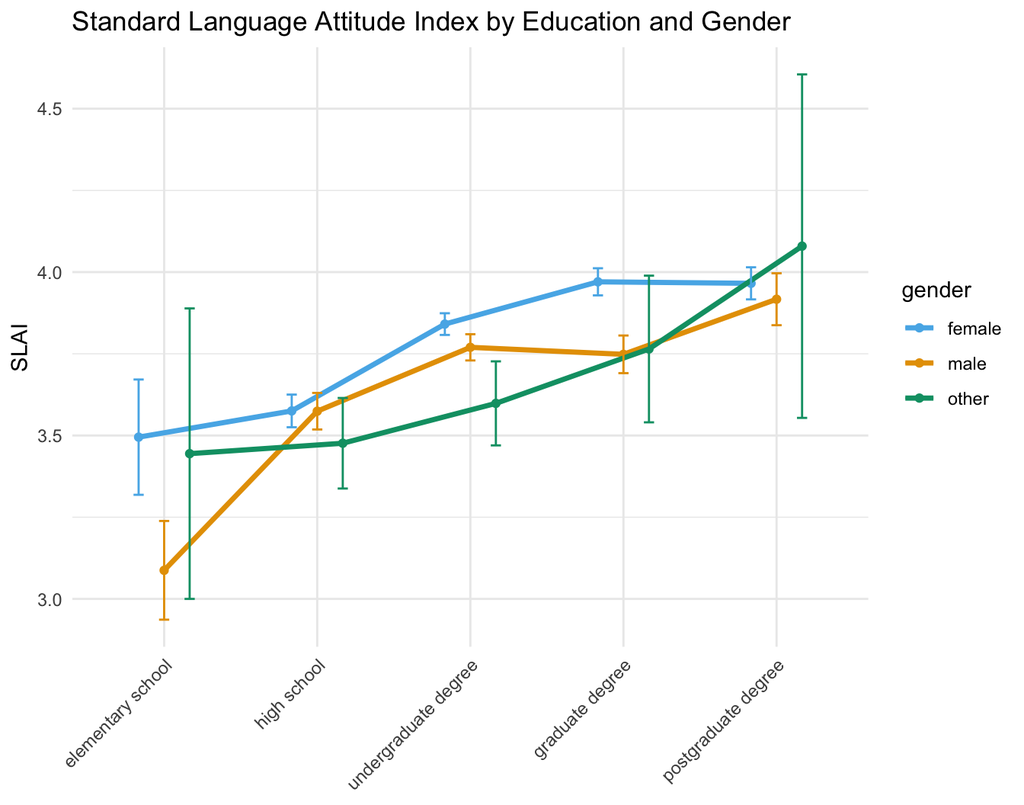

Figure 4

The difference between male and female participants is clearest among respondents with only elementary education *and* among those with a graduate degree.

And now: `edu` x `gender` x `umultiling.`

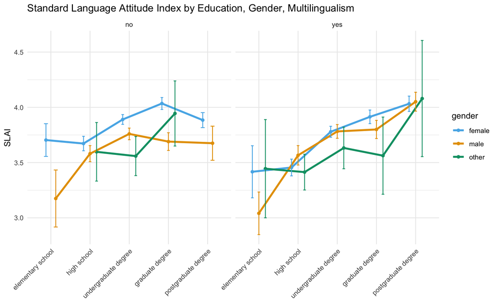

Figure 5

Among monolinguals, `gender` is clearly more important (lines are farther apart).  
Among bi-/multilinguals, `edu` is more important (slopes are greater).

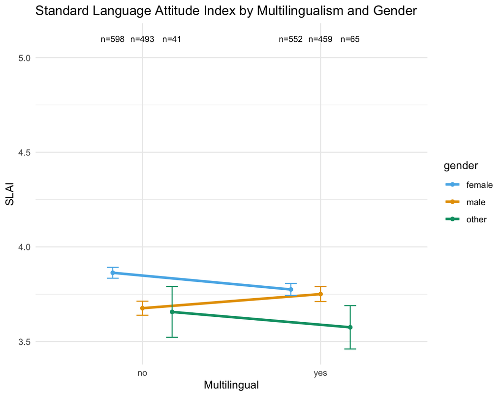

Figure 6

The multilingual factor interacts strongly with gender. Women who are multilingual are less positively oriented toward StCanE. Men who are multilingual show the opposite trend: they value the concept of StCanE more highly. **Notice that with the more focused SLAI, this gender difference is now even sharper than before.**

## 3 Statistical tests

From here until the end of the document, there are significant updates that are still outstanding, e.g. we had decided to focus more on `region` instead of `region`. We’ll get to that!

```
Call:
lm(formula = slai ~ region + gender + edu_comp, data = df_plot)

Residuals:
     Min       1Q   Median       3Q      Max
-2.91258 -0.45446  0.09639  0.55809  1.72317

Coefficients:
                             Estimate Std. Error t value Pr(>|t|)
(Intercept)                   3.23432    0.13626  23.736  < 2e-16 ***
regionAB                      0.17545    0.05389   3.256 0.001149 **
regionSK                      0.26448    0.06306   4.194 2.84e-05 ***
regionMB                      0.21078    0.06142   3.432 0.000611 ***
regionON                      0.25955    0.05271   4.925 9.08e-07 ***
regionPE                     -0.06704    0.13314  -0.503 0.614666
regionQC                     -0.13122    0.09048  -1.450 0.147135
regionNB                      0.05095    0.13715   0.372 0.710299
regionNS                      0.08676    0.12317   0.704 0.481296
regionNL                     -0.02590    0.13012  -0.199 0.842228
regionTR                     -0.02592    0.29147  -0.089 0.929140
regionUS                     -0.10752    0.07986  -1.346 0.178346
regionUK                      0.11318    0.14447   0.783 0.433472
gendermale                   -0.10278    0.03387  -3.035 0.002437 **
genderother                  -0.15023    0.07790  -1.928 0.053923 .
edu_comphigh school           0.27651    0.13721   2.015 0.043999 *
edu_compundergraduate degree  0.46748    0.13678   3.418 0.000643 ***
edu_compgraduate degree       0.54952    0.13923   3.947 8.17e-05 ***
edu_comppostgraduate degree   0.62479    0.14267   4.379 1.25e-05 ***
---
Signif. codes:  0 '***' 0.001 '**' 0.01 '*' 0.05 '.' 0.1 ' ' 1

Residual standard error: 0.7633 on 2189 degrees of freedom
Multiple R-squared:  0.06476,   Adjusted R-squared:  0.05707
F-statistic: 8.422 on 18 and 2189 DF,  p-value: < 2.2e-16
```

### 3.1 Anova test

```
Anova Table (Type II tests)

Response: slai
           Sum Sq   Df F value    Pr(>F)
region      36.60   12  5.2363 9.357e-09 ***
gender       6.42    2  5.5131   0.00409 **
edu_comp    34.01    4 14.5955 9.067e-12 ***
Residuals 1275.21 2189
---
Signif. codes:  0 '***' 0.001 '**' 0.01 '*' 0.05 '.' 0.1 ' ' 1
```

### 3.2 Interactions included in model

```
Anova Table (Type II tests)

Response: slai
                   Sum Sq   Df F value    Pr(>F)
region              35.29   12  5.0534 2.306e-08 ***
gender               6.47    2  5.5613  0.003898 **
edu_comp            33.10    4 14.2160 1.856e-11 ***
umultiling           0.06    1  0.1095  0.740762
gender:edu_comp      4.51    8  0.9687  0.458638
gender:umultiling    3.58    2  3.0739  0.046442 *
Residuals         1267.62 2178
---
Signif. codes:  0 '***' 0.001 '**' 0.01 '*' 0.05 '.' 0.1 ' ' 1
```

This shows that the `gender x edu` interaction term is **not** significant (at all), so we can stop talking about it.

```
Anova Table (Type II tests)

Response: slai
                   Sum Sq   Df F value    Pr(>F)
region              45.63   12  6.3806 3.047e-11 ***
gender              10.48    2  8.7923 0.0001573 ***
umultiling           0.45    1  0.7561 0.3846360
gender:umultiling    3.54    2  2.9679 0.0516179 .
Residuals         1305.23 2190
---
Signif. codes:  0 '***' 0.001 '**' 0.01 '*' 0.05 '.' 0.1 ' ' 1
```

### 3.3 Pairwise comparisons

Between education levels.

```
$emmeans
 edu_comp             emmean     SE   df lower.CL upper.CL
 elementary school      3.21 0.1400 2189     2.94     3.49
 high school            3.49 0.0487 2189     3.39     3.58
 undergraduate degree   3.68 0.0441 2189     3.59     3.77
 graduate degree        3.76 0.0516 2189     3.66     3.86
 postgraduate degree    3.84 0.0598 2189     3.72     3.95

Results are averaged over the levels of: region, gender
Confidence level used: 0.95

$contrasts
 contrast                                   estimate     SE   df t.ratio
 elementary school - high school             -0.2765 0.1370 2189  -2.015
 elementary school - undergraduate degree    -0.4675 0.1370 2189  -3.418
 elementary school - graduate degree         -0.5495 0.1390 2189  -3.947
 elementary school - postgraduate degree     -0.6248 0.1430 2189  -4.379
 high school - undergraduate degree          -0.1910 0.0418 2189  -4.572
 high school - graduate degree               -0.2730 0.0495 2189  -5.517
 high school - postgraduate degree           -0.3483 0.0585 2189  -5.952
 undergraduate degree - graduate degree      -0.0820 0.0447 2189  -1.837
 undergraduate degree - postgraduate degree  -0.1573 0.0547 2189  -2.878
 graduate degree - postgraduate degree       -0.0753 0.0606 2189  -1.243
 p.value
  0.2589
  0.0058
  0.0008
  0.0001
  0.0001
  <.0001
  <.0001
  0.3524
  0.0329
  0.7263

Results are averaged over the levels of: region, gender
P value adjustment: tukey method for comparing a family of 5 estimates
```

A better view of the output of the Anova for main effects.

| Term | Sum Sq | Df | F value | Pr(>F) | Signif. |
| --- | --- | --- | --- | --- | --- |
| region | 36.604916 | 12 | 5.24 | 0.000 | *** |
| gender | 6.423373 | 2 | 5.51 | 0.004 | ** |
| edu_comp | 34.010564 | 4 | 14.60 | 0.000 | *** |
| Residuals | 1275.206349 | 2189 | NA | NA |  |

### 3.4 Visualize pairwise comparisons

First: `region` and `umultilingual`.

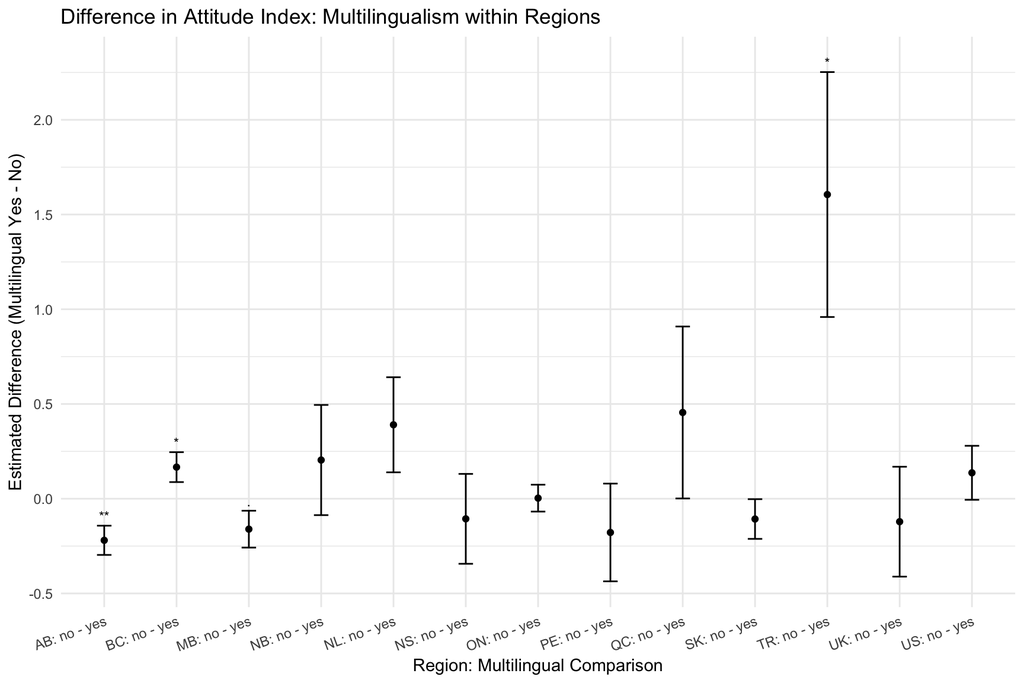

Figure 7

For our second pairwise comparison: `region` and `gender`.

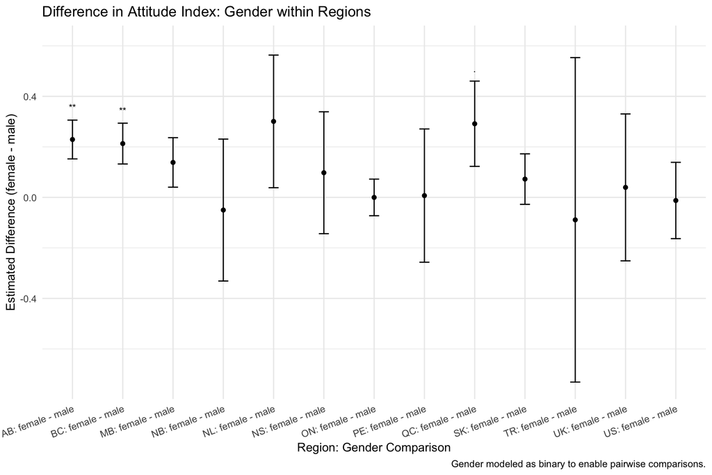

Figure 8

This is interesting, but in this approach, hardly anything is significant. It’s all a wash! See the table below.

| contrast_label | signif | estimate |
| --- | --- | --- |
| BC: female - male | ** | 0.2131 |
| AB: female - male | ** | 0.2293 |
| SK: female - male |  | 0.0725 |
| MB: female - male |  | 0.1384 |
| ON: female - male |  | -0.0001 |
| PE: female - male |  | 0.0071 |
| QC: female - male | . | 0.2916 |
| NB: female - male |  | -0.0501 |
| NS: female - male |  | 0.0976 |
| NL: female - male |  | 0.3009 |
| TR: female - male |  | -0.0889 |
| US: female - male |  | -0.0123 |
| UK: female - male |  | 0.0396 |

### 3.5 Multivariate model plot

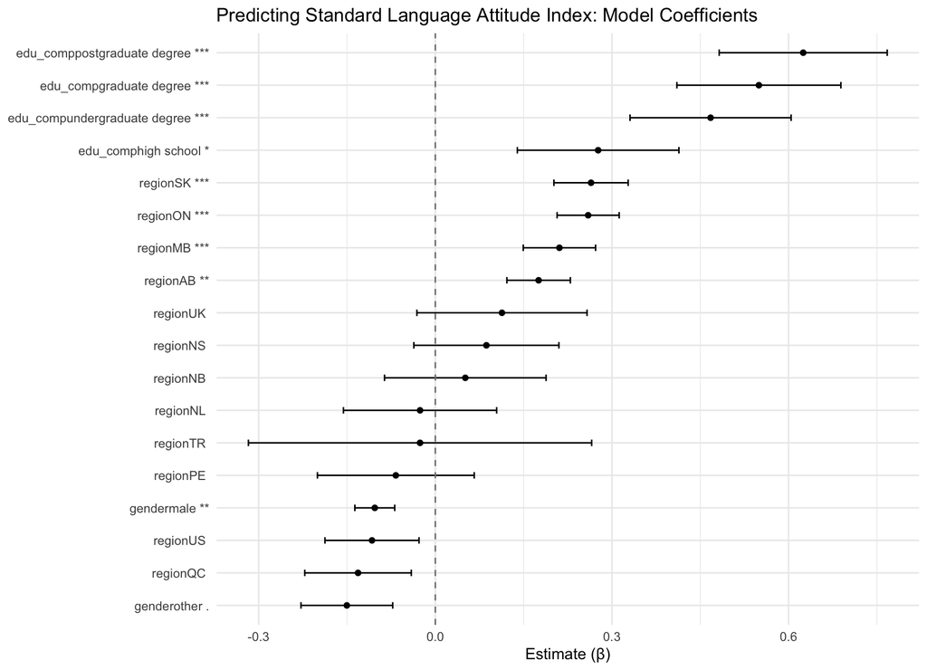

Figure 9